# ML Exam

Sagar Kalauni

2023-12-15

```r
set.seed(100)
library(datasets)
library(ISLR2)
library(tree)
library(randomForest)
library(boot)
```

```r
library(ggplot2)
library(e1071)
library(gbm)
library(nnet)
library(ISLR)
library(factoextra)
```

This problem involves the Caravan data set which is part of the ISLR2 package. Perform the following analysis. This is an imbalanced data set.

```r
library(ISLR2)
dim(Caravan)
```

```
## [1] 5822   86
```

```r
nrow(Caravan)
```

```
## [1] 5822
```

```r
#
standardize=function(x) {(x-min(x))/(max(x)-min(x))}
Caravan$MOSTYPE=standardize(Caravan$MOSTYPE)
#Caravan$MOSHOOFD=standardize(Caravan$MOSHOOFD)
```

```r
colnames(Caravan)
```

```
##  [1] "MOSTYPE"  "MAANTHUI" "MGEMOMV"  "MGEMLEEF" "MOSHOOFD" "MGODRK"
##  [7] "MGODPR"   "MGODOV"   "MGODGE"   "MRELGE"   "MRELSA"   "MRELOV"
## [13] "MFALLEEN" "MFGEKIND" "MFWEKIND" "MOPLHOOG" "MOPLMIDD" "MOPLLAAG"
## [19] "MBERHOOG" "MBERZELF" "MBERBOER" "MBERMIDD" "MBERARBG" "MBERARBO"
## [25] "MSKA"     "MSKB1"    "MSKB2"    "MSKC"     "MSKD"     "MHHUUR"
## [31] "MHKOOP"   "MAUT1"    "MAUT2"    "MAUT0"    "MZFONDS"  "MZPART"
## [37] "MINKM30"  "MINK3045" "MINK4575" "MINK7512" "MINK123M" "MINKGEM"
## [43] "MKOOPKLA" "PWAPART"  "PWABEDR"  "PWALAND"  "PPERSAUT" "PBESAUT"
## [49] "PMOTSCO"  "PVRAAUT"  "PAANHANG" "PTRACTOR" "PWERKT"   "PBROM"
## [55] "PLEVEN"   "PPERSONG" "PGEZONG"  "PWAOREG"  "PBRAND"   "PZEILPL"
## [61] "PPLEZIER" "PFIETS"   "PINBOED"  "PBYSTAND" "AWAPART"  "AWABEDR"
## [67] "AWALAND"  "APERSAUT" "ABESAUT"  "AMOTSCO"  "AVRAAUT"  "AAANHANG"
## [73] "ATRACTOR" "AWERKT"   "ABROM"    "ALEVEN"   "APERSONG" "AGEZONG"
## [79] "AWAOREG"  "ABRAND"   "AZEILPL"  "APLEZIER" "AFIETS"   "AINBOED"
## [85] "ABYSTAND" "Purchase"
```

1. It’s a large data. To reduce computational time (and just for illustration), let’s first create a training set containing the first 1000 observations, and a test set containing the next 300 observations.

```r
# Step 1: Split the data into training and testing sets
train_data=Caravan[1:1000, ]
test_data=Caravan[1001:1300, ]

train_index=1:1000
```

2. Fit a tree to the training data, with Purchase as the response and the other variables as predictors. Use the summary() function to produce summary statistics about the tree, and describe the results obtained. What is the training error rate? How many terminal nodes does the tree have?

```r
set.seed(100)
library(tree)
tree.d=tree(Purchase~., Caravan, split = 'gini', subset =train_index ) # except Purchase all other variables in the data set are be considered as predictors.
```

```r
summary(tree.d)
```

```
##
## Classification tree:
## tree(formula = Purchase ~ ., data = Caravan, subset = train_index,
##     split = "gini")
## Variables actually used in tree construction:
##  [1] "PPLEZIER" "PINBOED"  "PWABEDR"  "PGEZONG"  "PBYSTAND" "PPERSONG"
##  [7] "PAANHANG" "PFIETS"   "PWALAND"  "PTRACTOR" "PLEVEN"   "PMOTSCO"
## [13] "PBROM"    "MAANTHUI" "MKOOPKLA" "MBERARBG" "PPERSAUT" "MAUT2"
## [19] "MSKB1"    "MOPLLAAG" "MBERMIDD" "MHKOOP"   "MBERARBO" "APERSAUT"
## [25] "MINK123M" "PBRAND"   "MBERZELF" "MGODPR"   "MINK7512" "MGODRK"
## [31] "MOSTYPE"  "MBERBOER" "MSKD"     "MBERHOOG" "MINKM30"  "MSKA"
## [37] "MRELSA"   "MAUT0"    "MOSHOOFD" "MFALLEEN" "MGODGE"   "MGODOV"
## [43] "MFWEKIND" "MZPART"   "MSKC"
## Number of terminal nodes:  63
## Residual mean deviance:  0.2391 = 224 / 937
## Misclassification error rate: 0.058 = 58 / 1000
```

This is a classification tree, we have a total number of terminal node of 63, so it’s a big tree. we have mean deviance: 0.2391 , which is calculated deviance divided by total number of training observation minus the number of terminal nodes. We also have Misclassification error rate: 0.058, which is calculated as Number of Misclassification divided by total training set.

we see that the training error rate is 5.8%. The residual mean deviance reported is simply the deviance divided by $n-|T_0|$, which in this case is 1000-63= 937.

2. Create a plot of the tree. Pick one of the terminal nodes, and interpret the information displayed.

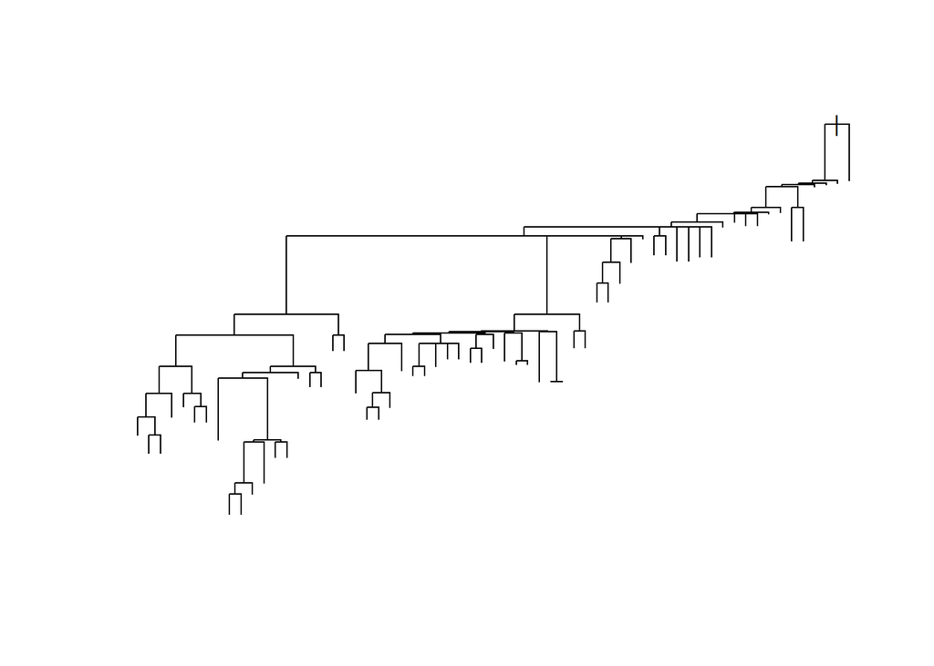

```r
plot(tree.d)  # for Plotting the decision tree
```

```r
#text(tree.d, pretty= 0) #if you want to see labels also
```

```r
set.seed(100)
tree.d
```

```
## node), split, n, deviance, yval, (yprob)
##       * denotes terminal node
##
##        1) root 1000 448.400 No ( 0.94100 0.05900 )
##          2) PPLEZIER < 0.5 992 425.100 No ( 0.94456 0.05544 )
##            4) PINBOED < 0.5 987 424.500 No ( 0.94428 0.05572 )
##              8) PWABEDR < 0.5 978 417.800 No ( 0.94479 0.05521 )
##               16) PGEZONG < 1 969 411.100 No ( 0.94530 0.05470 )
##                 32) PBYSTAND < 1 956 392.400 No ( 0.94770 0.05230 )
##                   64) PPERSONG < 1 947 391.400 No ( 0.94720 0.05280 )
##                    128) PAANHANG < 0.5 937 384.600 No ( 0.94771 0.05229 )
##                      256) PFIETS < 0.5 920 377.000 No ( 0.94783 0.05217 )
##                        512) PWALAND < 1.5 904 375.200 No ( 0.94690 0.05310 )
##                         1024) PTRACTOR < 1.5 894 374.100 No ( 0.94631 0.05369 )
##                           2048) PLEVEN < 0.5 863 359.200 No ( 0.94670 0.05330 )
##                             4096) PMOTSCO < 2 830 344.100 No ( 0.94699 0.05301 )
##                               8192) PBROM < 1 775 332.300 No ( 0.94452 0.05548 )
##                                16384) MAANTHUI < 1.5 700 301.000 No ( 0.94429 0.05571 )
##                                  32768) MKOOPKLA < 5.5 488 134.000 No ( 0.96926 0.03074 )
##                                    65536) MBERARBG < 6.5 478 119.400 No ( 0.97280 0.02720 )
##                                     131072) PPERSAUT < 5.5 315  42.880 No ( 0.98730 0.01270 )
##                                       262144) MAUT2 < 2.5 295  23.960 No ( 0.99322 0.00678 )
##                                         524288) MSKB1 < 4.5 289  13.330 No ( 0.99654 0.00346 )
##                                          1048576) MOPLLAAG < 7.5 249   0.000 No ( 1.00000 0.00000 ) *
##                                          1048577) MOPLLAAG > 7.5 40   9.353 No ( 0.97500 0.02500 )
##                                            2097154) MBERMIDD < 3.5 34   0.000 No ( 1.00000 0.00000 ) *
##                                            2097155) MBERMIDD > 3.5 6   5.407 No ( 0.83333 0.16667 ) *
##                                         524289) MSKB1 > 4.5 6   5.407 No ( 0.83333 0.16667 ) *
##                                       262145) MAUT2 > 2.5 20  13.000 No ( 0.90000 0.10000 )
##                                         524290) MHKOOP < 6.5 10   0.000 No ( 1.00000 0.00000 ) *
##                                         524291) MHKOOP > 6.5 10  10.010 No ( 0.80000 0.20000 )
##                                          1048582) MBERARBO < 1.5 5   0.000 No ( 1.00000 0.00000 ) *
##                                          1048583) MBERARBO > 1.5 5   6.730 No ( 0.60000 0.40000 ) *
##                                     131073) PPERSAUT > 5.5 163  69.630 No ( 0.94479 0.05521 )
##                                       262146) APERSAUT < 1.5 147  56.280 No ( 0.95238 0.04762 )
##                                         524292) MINK123M < 0.5 135  55.060 No ( 0.94815 0.05185 )
##                                          1048584) PBRAND < 2.5 82   0.000 No ( 1.00000 0.00000 ) *
##                                          1048585) PBRAND > 2.5 53  41.370 No ( 0.86792 0.13208 )
##                                            2097170) MBERZELF < 0.5 43  30.910 No ( 0.88372 0.11628 )
##                                              4194340) MGODPR < 4.5 19  21.900 No ( 0.73684 0.26316 )
```

[output cut: 73 more lines]

```
##                             4099) MSKC > 4.5 7   8.376 No ( 0.71429 0.28571 ) *
##                         1025) PTRACTOR > 1.5 10   0.000 No ( 1.00000 0.00000 ) *
##                        513) PWALAND > 1.5 16   0.000 No ( 1.00000 0.00000 ) *
##                      257) PFIETS > 0.5 17   7.606 No ( 0.94118 0.05882 )
##                        514) MGODRK < 1.5 12   0.000 No ( 1.00000 0.00000 ) *
##                        515) MGODRK > 1.5 5   5.004 No ( 0.80000 0.20000 ) *
##                    129) PAANHANG > 0.5 10   6.502 No ( 0.90000 0.10000 ) *
##                   65) PPERSONG > 1 9   0.000 No ( 1.00000 0.00000 ) *
##                 33) PBYSTAND > 1 13  14.050 No ( 0.76923 0.23077 )
##                   66) MBERMIDD < 3.5 8   0.000 No ( 1.00000 0.00000 ) *
##                   67) MBERMIDD > 3.5 5   6.730 Yes ( 0.40000 0.60000 ) *
##               17) PGEZONG > 1 9   6.279 No ( 0.88889 0.11111 ) *
##              9) PWABEDR > 0.5 9   6.279 No ( 0.88889 0.11111 ) *
##            5) PINBOED > 0.5 5   0.000 No ( 1.00000 0.00000 ) *
##          3) PPLEZIER > 0.5 8  11.090 No ( 0.50000 0.50000 ) *
```

3. Produce a pruned tree corresponding to the optimal tree size using cross-validation. Which tree size corresponds to the lowest cross-validated classification error rate? Call this your model #1.

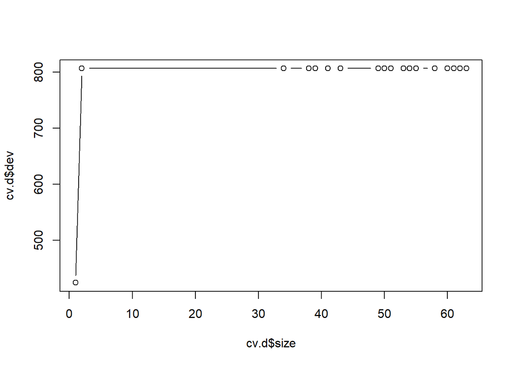

```r
cv.d=cv.tree(tree.d)
plot(cv.d$size, cv.d$dev, type="b")
```

```r
cv.d
```

```
## $size
##  [1] 63 62 61 60 58 55 54 53 51 50 49 43 41 39 38 34  2  1
##
## $dev
##  [1] 806.6980 806.6980 806.6980 806.6980 806.6980 806.6980 806.6980 806.6980
##  [9] 806.6980 806.6980 806.6980 806.6980 806.6980 806.6980 806.6980 806.6980
## [17] 806.6980 424.1166
##
## $k
##  [1]        -Inf  0.05231234  0.75410643  2.04689946  2.60239035  2.74882849
##  [7]  3.03662721  3.05928285  3.13660113  3.15811171  3.18898175  3.25807916
## [13]  3.27793180  3.42640701  3.61628211  3.64919682  3.93616155 12.26827243
##
## $method
## [1] "deviance"
##
## attr(,"class")
## [1] "prune"         "tree.sequence"
```

```r
model_1=prune.d=prune.tree(tree.d,best=2)
summary(prune.d)
```

```
##
## Classification tree:
## snip.tree(tree = tree.d, nodes = 2L)
## Variables actually used in tree construction:
## [1] "PPLEZIER"
## Number of terminal nodes:  2
## Residual mean deviance:  0.437 = 436.1 / 998
## Misclassification error rate: 0.059 = 59 / 1000
```

```r
pred.prune.d=predict(prune.d,test_data,type="class")
table(pred.prune.d,test_data$Purchase)
```

```
##
## pred.prune.d  No Yes
##          No  282  18
##          Yes   0   0
```

4. Fit a boosting model to the training set with Purchase as the response label and the other variables as features. Use 1,000 trees, and a shrinkage value of 0.01. Call this your model #2. Which predictor appear to be the most important?

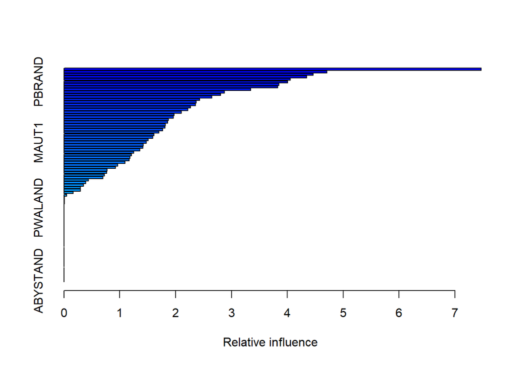

```
##               var     rel.inf
## PPERSAUT PPERSAUT 7.470630643
## MGODGE     MGODGE 4.711731856
## MKOOPKLA MKOOPKLA 4.465713856
## MOPLHOOG MOPLHOOG 4.349066063
## MOSTYPE   MOSTYPE 4.055714391
## PBRAND     PBRAND 4.004838117
## MINK3045 MINK3045 3.847254554
## MBERMIDD MBERMIDD 3.826022011
## MGODPR     MGODPR 3.346766550
## MBERARBG MBERARBG 2.876262003
## MSKC         MSKC 2.807521364
## MSKA         MSKA 2.650297607
## MAUT2       MAUT2 2.430456970
## MSKB1       MSKB1 2.367871627
## MINK7512 MINK7512 2.352940169
## MGODOV     MGODOV 2.263662272
## MFGEKIND MFGEKIND 2.217892681
## MFWEKIND MFWEKIND 2.100219570
## MRELOV     MRELOV 1.974073598
## MBERARBO MBERARBO 1.958784153
## MAUT0       MAUT0 1.867785685
## MRELGE     MRELGE 1.854221157
## MSKB2       MSKB2 1.814082871
## MINKGEM   MINKGEM 1.805489234
## PWAPART   PWAPART 1.769056217
## MINKM30   MINKM30 1.699308117
## MFALLEEN MFALLEEN 1.612947930
## MBERHOOG MBERHOOG 1.591361700
## MHHUUR     MHHUUR 1.507613792
## MAUT1       MAUT1 1.471996800
## MZPART     MZPART 1.421476110
## MZFONDS   MZFONDS 1.415684057
## MOPLMIDD MOPLMIDD 1.360295568
## MRELSA     MRELSA 1.249358252
## MINK4575 MINK4575 1.211076895
## MGEMLEEF MGEMLEEF 1.180946915
## ABRAND     ABRAND 1.168346161
## MSKD         MSKD 1.091191732
## MBERZELF MBERZELF 0.960556069
```

[output cut: 31 more lines]

```
## ABESAUT   ABESAUT 0.000000000
## AMOTSCO   AMOTSCO 0.000000000
## AVRAAUT   AVRAAUT 0.000000000
## AAANHANG AAANHANG 0.000000000
## ATRACTOR ATRACTOR 0.000000000
## AWERKT     AWERKT 0.000000000
## ABROM       ABROM 0.000000000
## APERSONG APERSONG 0.000000000
## AGEZONG   AGEZONG 0.000000000
## AWAOREG   AWAOREG 0.000000000
## AZEILPL   AZEILPL 0.000000000
## APLEZIER APLEZIER 0.000000000
## AFIETS     AFIETS 0.000000000
## AINBOED   AINBOED 0.000000000
## ABYSTAND ABYSTAND 0.000000000
```

```r
train_data$Purchase = factor(train_data$Purchase, levels=c("No","Yes"), labels=c(0,1))
train_data$Purchase = as.integer(train_data$Purchase)-1

model_2= gbm(Purchase ~ ., data=train_data, distribution="bernoulli",
n.trees=1000, interaction.depth=4, shrinkage=0.01)
summary(model_2)
```

predictor PPERSAUT appear to be the most important

5. Use the boosting model to predict the response on the test data. Predict that a person will make a purchase if the estimated probability of purchase is greater than 20%.

```r
set.seed(100)
glm.probs=predict(model_2 , test_data, type = "response")
```

```
## Using 1000 trees...
```

```r
glm.pred <- rep("No", 300)
glm.pred[glm.probs > .2] = "Yes"
```

```r
glm.pred[1:10][1:10] # first 10 prediction
```

```
##  [1] "No"  "No"  "No"  "No"  "Yes" "No"  "No"  "No"  "No"  "No"
```

```r
(cm <- table(test_data$Purchase, glm.pred))
```

```
##      glm.pred
##        No Yes
##   No  274   8
##   Yes  18   0
```

6. Fit a radial kernel SVM to the training data with Purchase as the label and the other variables as features. Use a cost value of 0.01, and a gamma value of 0.5 . Call this your model #3.

```r
# Fitting a linear model with cost=0.01
Model_3 = svm(Purchase ~ ., data =train_data, kernel = "radial", gamma=0.5, cost =0.01, scale = FALSE)
summary(Model_3)
```

```
##
## Call:
## svm(formula = Purchase ~ ., data = train_data, kernel = "radial",
##     gamma = 0.5, cost = 0.01, scale = FALSE)
##
##
## Parameters:
##    SVM-Type:  eps-regression
##  SVM-Kernel:  radial
##        cost:  0.01
##       gamma:  0.5
##     epsilon:  0.1
##
##
## Number of Support Vectors:  936
```

```r
svm.pred.test=predict(Model_3, test_data, type="response")
table(svm.pred.test, test_data$Purchase)
```

[output not shown]

[output cut: 152 more lines]

[output not shown]

7. Generate confusion matrix for the test set predictions for Model 1,2,3. Discuss your findings. Which model did better in terms of overall test error? How about in terms of Recall?

```r
table(pred.prune.d,test_data$Purchase)
```

```
##
## pred.prune.d  No Yes
##          No  282  18
##          Yes   0   0
```

```r
(cm <- table(test_data$Purchase, glm.pred))
```

```
##      glm.pred
##        No Yes
##   No  274   8
##   Yes  18   0
```

```r
table(svm.pred.test, test_data$Purchase)
```

[output not shown]

[output cut: 152 more lines]

[output not shown]